# LabReport3_key

# Numerical solutions in R, Lab 3

The goal of today’s lab is for you to learn how to numerically solve ecological models in R. The two types that you’ll learn to solve are difference (discrete-time) equations and differential (continous-time) equations. You’ve already learned how to loop over a difference equation to solve (synonymous with “simulate”) it. Today you will learn how to solve difference equations using a different method (using the function used for differential equations in pacakge `"deSolve"`). Next, you will learn how to solve differential equations, something we have not yet covered. There are *many* approches to solving differential equations by integration (also known as initial-value problems), but we will only use on a single, robust method. This method is known as LSODA, and it stands for **L**ivermore **S**olver for **O**rdinary **D**ifferential equations, **A**utomatic. The “automatic” refers to the method’s ability to automatically switch between subroutines that will yield a more accurate answer, especially with highly nonlinear equations. (I.e., you’re generally in good shape with LSODA.) Lastly, today you’ll learn how to solve equations while changing one parameter many times.

## 1. Discrete equations

### Using `"deSolve"` to solve difference equations

1.1 Write a loop for the discrete logistic equation (below), with an initial population size of 0.05, a natural rate of increase as 1.2, and a crowding coefficient ($\alpha$) of 0.05. Run for 49 time steps and plot the time series.
$$N_{t+1} = \lambda N_t - \alpha N_t^2$$

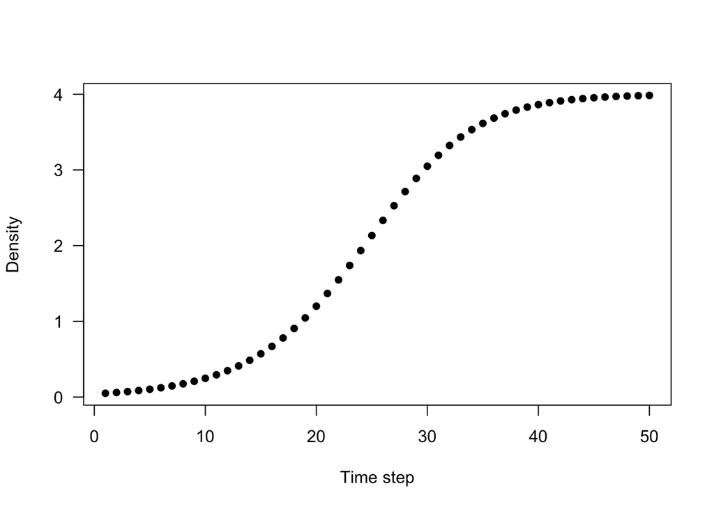

```r
N0_1.1 <- 0.05
n.steps_1.1 <- 50
vec.steps_1.1 <- 1:n.steps_1.1
N_1.1 <- vector(mode = "numeric", length = n.steps_1.1)
N_1.1[1] <- N0_1.1
for (i in 2:n.steps_1.1) {
  N_1.1[i] <- 1.2*N_1.1[i-1] - 0.05*N_1.1[i-1]^2
}
plot(x = vec.steps_1.1, y = N_1.1, xlab = "Time step", ylab = "Density", pch = 16, las = 1)
```

1.2 Next, you are going to do the same thing as 1.1, but using the function `ode()` in the package `"deSolve"`. A “package” is essentially an R program that is full of functions for you to use when you load it into R. There are many different ways of acquiring packages, like through downloading it from CRAN (Comprehensive R Archive Network) or GitHub (a repository for code) or writing your own, but I’ve already downloaded a version of `"deSolve"` to the server, so you don’t need to worry about downloading it. Now, all you need to do is load the pacakge into your current workspace. Do this by using the function `library()` and specifying the argument `package =`, followed by the pacakge name as a character string (i.e., with quotes around it). Load `"deSolve"`.

```r
library(package = "deSolve")
```

Now that `"deSolve"` is loaded, you can use its suite of functions. The function that we will be using relatively extensively throughout the course is `ode()`, which stands for **o**rdinary **d**ifferential **e**quation. This solver is actually written in Fortran (yes, *that* Fortran that appeared in **1956** and has recently been popularly recognized through the Hollywood blockbuster, *Hidden Figures*) and requires that you pass on special arguments. Go to `ode()`’s documentation by running `?ode`. Read over the four main arguments in the **Arguments** section and summarize them in your own words.

```r
?ode
```

`ode()` takes four arguments

1. `y` requires the initial conditions
2. `times` requires the time sequence for the output (as a vector)
3. `func` requires a function with first three arguments defined as `t, y, parms` and create a list to be returned by `return()`
4. `method` requires whichever integrator the user needs; defaults to `lsoda`

It’s important to note that the documentation for R pacakges is standardized, so it always has a description, usage, details, value (what the function actually returns—a matrix, in `ode()`’s case), etc., and examples. See Example3. It’s a more complex model that we will be studying later in the semester; namely, it involves two species, a parasite and a host. Copy it up to the end of `out <- ode(...)`, paste it, and run it. Use `str()` and `head()` to examine the object. Plot the time steps against the density of the parasites and hosts on a single graph. Make sure to label your axes and incude all the data within the plotting region.

```r
Parasite <- function(t, y, ks) {
  P <- y[1]
  H <- y[2]
  f    <- A * P / (ks + H)
  Pnew <- H * (1 - exp(-f))
  Hnew <- H * exp(rH * (1 - H) - f)

  list (c(Pnew, Hnew))
}
rH <- 2.82 # rate of increase
A  <- 100  # attack rate
ks <- 15   # half-saturation density

out <- ode(func = Parasite, y = c(P = 0.5, H = 0.5), times = 0:50, parms = ks,
           method = "iteration")

str(out)
```

```
##  deSolve [1:51, 1:3] 0 1 2 3 4 5 6 7 8 9 ...
##  - attr(*, "istate")= int [1:21] 0 51 52 NA NA NA NA NA NA NA ...
##  - attr(*, "dimnames")=List of 2
##   ..$ : NULL
##   ..$ : chr [1:3] "time" "P" "H"
##  - attr(*, "lengthvar")= int 2
##  - attr(*, "type")= chr "iteration"
```

```r
head(out)
```

```
##      time          P          H
## [1,]    0 0.50000000 0.50000000
## [2,]    1 0.48013813 0.08135332
## [3,]    2 0.07798253 0.04495811
## [4,]    3 0.01818491 0.39568533
## [5,]    4 0.04408246 1.93269308
## [6,]    5 0.44299263 0.10735444
```

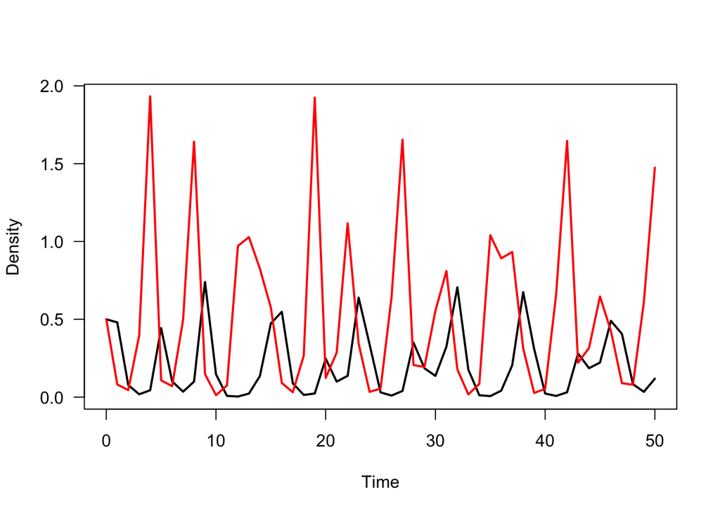

```r
plot(out[,1], out[,2], type = "l", ylim = c(0, max(out[,2], out[,3])), xlab = "Time", ylab = "Density", las = 1, lwd = 2)
lines(out[,1], out[,3], col = "red", lwd = 2)
```

Lastly, I would like for you to use the host-parasite example to build your own function for the discrete logistic problem from 1.1. After you’ve successfully done so, compare the data (graphically, verbally) between your `for()` loop and using this approach, `ode()`.

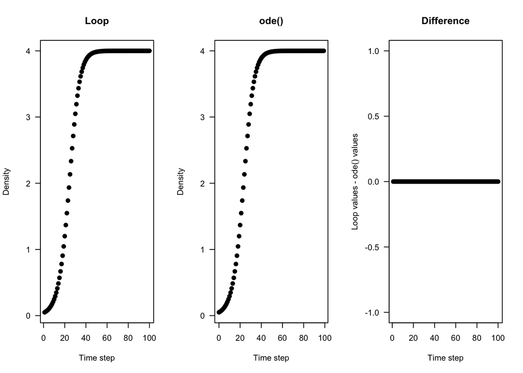

```r
runs <- 100
N_loop_1.2 <- vector("numeric", runs)
N0_1.2 <- N0_1.1
N_loop_1.2[1] <- N0_1.2

for (i in 2:runs) {
  N_loop_1.2[i] <- 1.2*N_loop_1.2[i-1] - 0.05*N_loop_1.2[i-1]^2
}


disc.log <- function(t, N, parms) {
   Nt1 <- 1.2*N - 0.05*N^2
  return(list(Nt1))
}


ode.out <- ode(func = disc.log, y = c(N = N0_1.2), times = 0:(runs - 1), parms = NA, method = "iteration")

par(mfrow = c(1, 3))
plot(1:runs, N_loop_1.2, xlab = "Time step", ylab = "Density", las = 1, pch = 16, cex = 1.25, main = "Loop")
plot(ode.out[,1], ode.out[,2], xlab = "Time step", ylab = "Density", las = 1, pch = 16, cex = 1.25, main = "ode()")
#N_loop_1.2-ode.out[,2]
plot(1:runs, N_loop_1.2-ode.out[,2], las = 1, xlab = "Time step", pch = 16, cex = 1.25, main = "Difference", ylab = "Loop values - ode() values")
```

Writing the difference equation in a `for()` loop or in `ode()` yields the same results, as exemplified by the figure above; specifically, the third panel where I subtract one from the other.

## 2. Differential equations

### Using `"deSolve"` to solve differential equations

2.1 In problem 1 you presumably found that there is no difference between solving difference equations using a `for()` loop and the function `ode()`. In 1.2, you probabaly also noticed the preponderance of `methods` arguments in `ode()`. Knowing the differences between them is not imprtant. What is important, however, is that to solve the difference equations, the `method = "iteration"`. This means that `ode()` treats the function like a difference equation and solves it through iteration For differential models, however, we mustn’t iterate because that will lead to inaccurate answers. Instead, we must integrate. As noted in the introduction of this Lab Report, this is usingn the method `lsoda`. This is the default method in `ode()`. You can specify `method = "lsoda"`, but it isn’t completely necessary (although, I think it’s a good habit to form). Now, in the `ode()` documentation, go to Example1, copy up to `plot()` in the `## Default plot method`, paste, run, and examine the output using `str()` and `head()`. This, like Example3, is a more complex model (two-species, Lotka-Volterra predator-prey model) that we will be learning about in week 7 (in April). Plot a time series of prey and predator density on the vertical axis and time on the horizontal axis. Next, just for fun, plot the model in “state space” by putting each of the state variables (predator and prey) on their own axis. That is, plot the prey density on the horizontal axis and the predator density on the vertical axis. What do you see? Is any of this reminding you of BI271?

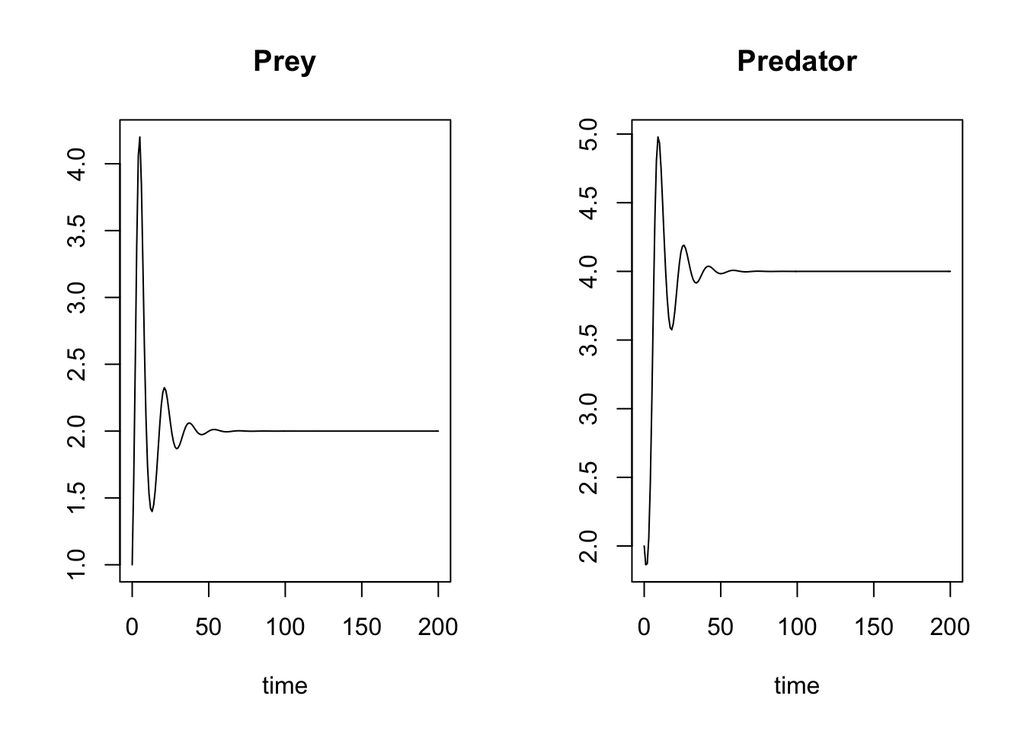

```r
## =======================================================================
## Example1: Predator-Prey Lotka-Volterra model (with logistic prey)
## =======================================================================

LVmod <- function(Time, State, Pars) {
  with(as.list(c(State, Pars)), {
    Ingestion    <- rIng  * Prey * Predator
    GrowthPrey   <- rGrow * Prey * (1 - Prey/K)
    MortPredator <- rMort * Predator

    dPrey        <- GrowthPrey - Ingestion
    dPredator    <- Ingestion * assEff - MortPredator

    return(list(c(dPrey, dPredator)))
  })
}

pars  <- c(rIng   = 0.2,    # /day, rate of ingestion
           rGrow  = 1.0,    # /day, growth rate of prey
           rMort  = 0.2 ,   # /day, mortality rate of predator
           assEff = 0.5,    # -, assimilation efficiency
           K      = 10)     # mmol/m3, carrying capacity

yini  <- c(Prey = 1, Predator = 2)
times <- seq(0, 200, by = 1)
out   <- ode(yini, times, LVmod, pars)

summary(out)
##                Prey    Predator
## Min.      1.0000000   1.8632829
## 1st Qu.   1.9999571   3.9999115
## Median    2.0000000   4.0000000
## Mean      2.0317905   3.9606228
## 3rd Qu.   2.0000751   4.0000418
## Max.      4.2001812   4.9787222
## N       201.0000000 201.0000000
## sd        0.3138139   0.3489079
head(out)
##      time     Prey Predator
## [1,]    0 1.000000 2.000000
## [2,]    1 1.626853 1.863283
## [3,]    2 2.488467 1.871156
## [4,]    3 3.408712 2.058948
## [5,]    4 4.060260 2.457730
## [6,]    5 4.200181 3.055230

## Default plot method
plot(out)
```

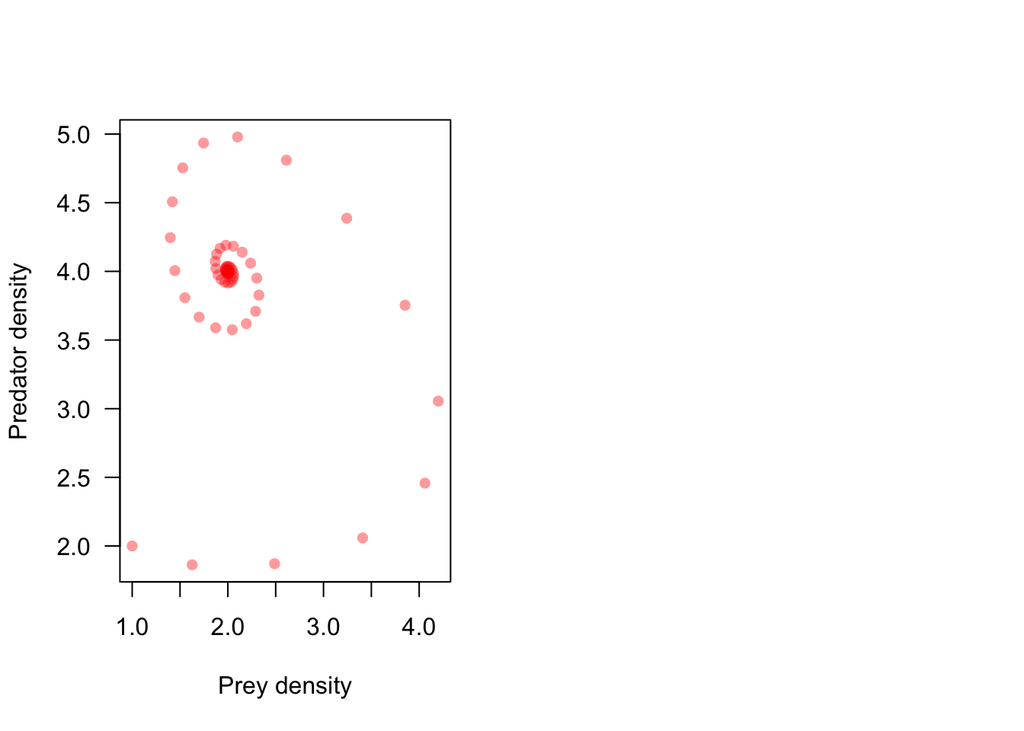

```r
plot(out[,2], out[,3], col = "#FF000066", pch = 16, las = 1, xlab = "Prey density", ylab = "Predator density")
```

2.2 Like problem 1, modify the example to create a differential model of the logistic equation, using the same parameter values. Plot both the difference equation time series and the differential time series on two plots. Verbally describe the differences between the two.

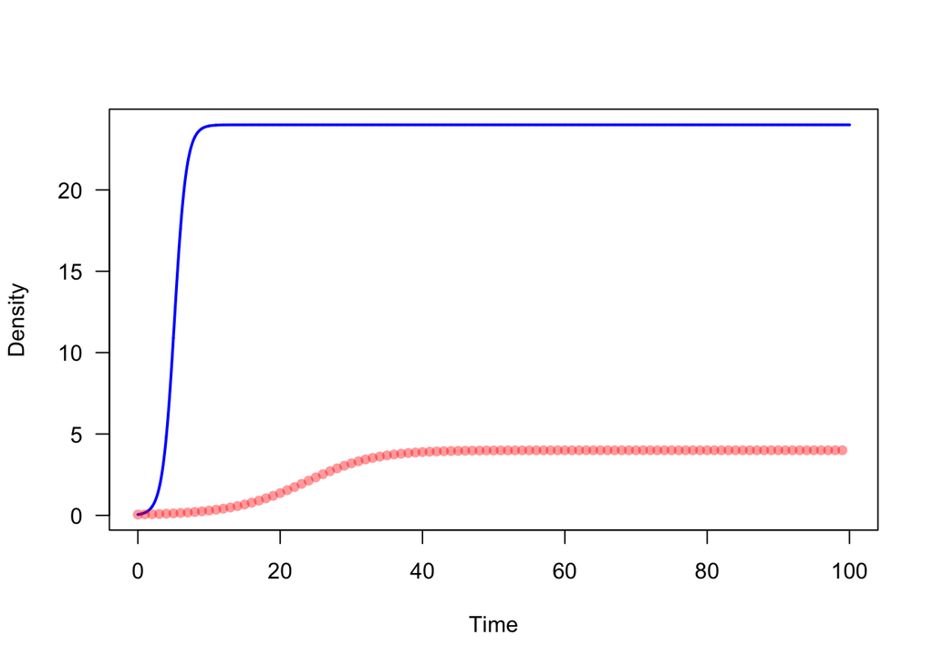

```r
cont.log <- function(t, N, parms) {
   dNdt <- 1.2*N - 0.05*N^2
   return(list(dNdt))
  }

N0_2.2 <- 0.05
time.seq <- seq(0, 100, by = 0.01)
cont.out <- ode(y = N0_2.2, times = time.seq, func = cont.log)

## Default plot method
plot(x = cont.out[,1], y = cont.out[,2], las = 1, type = "l", lwd = 2, col = "blue", xlab = "Time", ylab = "Density")
points(x = ode.out[,1], y = ode.out[,2], pch = 16, cex = 1, col = "#FF000066")
```

For the same paramter values, the differential equation has a greater positive equilibirum value (around 24 compared to around 4 with the discrete equation).

2.3 Use `ode()` to numerically solve and plot equation 17 from the book. Use the value of $\lambda$ from 1.1 and set $K$ to the equilibrium $\left(\frac{dN}{dt} = 0\right)$ from 2.1 (you can visually estimate this value).

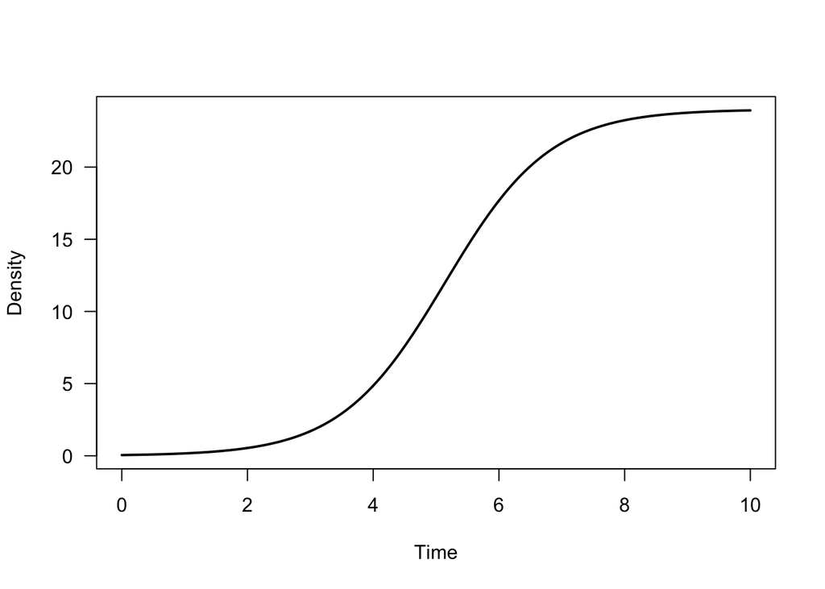

```r
eq17 <- function(t, N, parms) {
   dNdt <- 1.2*N*((24 - N)/24)
   return(list(dNdt))
}

N0_2.3 <- 0.05
time.seq_2.3 <- seq(0, 10, by = 0.01)
out_2.3 <- ode(y = N0_2.3, times = time.seq_2.3, parms = NA, func = eq17, method = "lsoda")
plot(x = out_2.3[,1], y = out_2.3[,2], las = 1, xlab = "Time", ylab = "Density", type = "l", lwd = 2)
```

## 3. Examining multiple parameters with `for()` (SKIP)

3.1 By this point, you have been able to numerically find solutions for both difference and differential equations. But, one of the “problems” with finding numerical solutions is that it’s for a single set of paramter values. In 1.1 we set $\lambda$ and $\alpha$ with single values; the same with 2.1 and 2.3. What do we do if we want to numerically solve for *multiple* parameters? The short answer is that we must assign parameter values individually and run the simulation. For instance, if we want to see how $\alpha$ affects the long-term population density, we would create a sequence of $\alpha$ values, simulate all of them individually, and analyze the outcome. So far we’ve looped by creating a vector, and indexing that vector (with the `i`s, `i+1`s, and i`-1`s) to recall a value for calculaiton and saving. Next, let’s try looping **over** our loops across **a range of parameter values**—this is what is referred to as a *nested loop*. To do so, I give verbal directions below, but first, type how you think that would work before you attempt it.

After you’ve brainstormed a bit, here are the following verbal directions: First, create a matrix that is going to save each iteration to each row. That means we want the number of rows to be as long as the number of $\alpha$ values and the columns to be as long as the number of time steps (it was 49). This is going to be the matrix that we populate with our values. Next, we want to loop the discrete logisitc equation from 1.1, with the same lambda, but with 21 $\alpha$ values ranging from 0.01 to 0.21. Write that loop. Around that loop, write another `for()` loop, but use `j in` instead of `i in`. Now, when you are indexing your density values (e.g., `Nt`), since you are working in a matrix, remember that that to index values, that it’s `object[rows, columns]`. You want to place you `i`s and `j`s in there. I want you to learn by trial and error. Everything you need should be here. When you have successfully created your nested loop, plot a time series of all values of $\alpha$ on a single plot.

3.2. Here is another nested loop problem. But instead of saving the entire times series in a row of a matrix, I’d like for you to save the last value (since it’s logistic, and if it’s not changing, then this is an equilibrium value). Using the Ricker equation from your book (eqn. 30). Write a nested loop that changes the value of $b$ from 10 values of $b$ between 0.1 and 1, and changes $r$ with 10 values between 0.1 and 0.5. Save these data in a matrix, and plot the matrix using `image()`. Verbally describe what patterns you see.